# LEP

SJTW

1/29/2020

## Figure 1

Figure 1 is a heatmap showing the resistances of the experimentally evolved isolates. Data used was a log2 transformation of the MIC of the resistant mutants relative to the starter strain P.aeruginosa PAO1. Due to the MIC testing going up in a doubling concentration, using a log2 normalization provided the best resolution and distribution of the data.

Raw MIC values were added to the heatmap using Adobe Illustrator, and labels were shifted to ensure high clarity in the final figue.

```r
require(ggplot2)
require(data.table)
load("~/mic_heat2")
mic_heat2
```

```
##       cultureID M2 I2 T2 G2 C2 L2
##  1:    PAO1_ILL  0  0  0  0  0  0
##  2: PAO1_ILL(6)  0  0  0  0  0  0
##  3:          C1  0 -1 -1 -1 11  9
##  4:          C2 -4 -3  0 -2 10  8
##  5:          C3 -1 -3  0 -1  9  8
##  6:          C4  0 -3 -1 -1 11  9
##  7:          C5  0 -1  0  0 10  7
##  8:          C6  0 -1 -2 -2 11  8
##  9:          C7  0 -3  0  1 10  9
## 10:          C8  0 -1  0  0  9  8
## 11:          C9  0  0 -2 -2 11  8
## 12:         C10  0  0 -2 -2  8  7
## 13:         C11 -1 -1  0 -1  8  6
## 14:         C12  0 -1  0 -1  8  7
```

[output cut: 28 more lines]

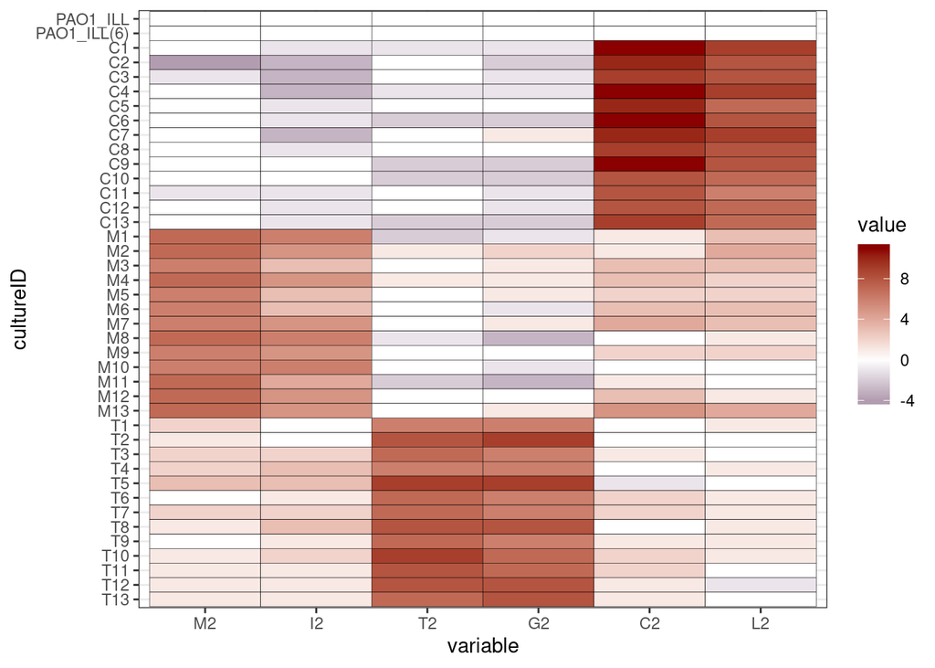

```r
misizzle.2 <- melt(mic_heat2)
misizzle.2$cultureID <- factor(misizzle.2$cultureID, levels = rev(c("PAO1_ILL", "PAO1_ILL(6)", "C1", "C2", "C3", "C4", "C5", "C6", "C7", "C8", "C9", "C10", "C11", "C12", "C13", "M1", "M2", "M3", "M4", "M5", "M6", "M7", "M8", "M9", "M10", "M11", "M12", "M13", "T1", "T2", "T3", "T4", "T5", "T6", "T7", "T8", "T9", "T10", "T11", "T12", "T13")), ordered = TRUE)

pzol2 <- ggplot(misizzle.2, aes(variable, cultureID)) + geom_tile(aes(fill = value), colour="black") + scale_fill_gradient2(low="#330033", mid="white", high ="darkred", space = "Lab") + theme_bw()

pzol2
```

## Figure 2

This figure shows the differences in Area Under growth Curve (AUC) computed from OD600 measurements of shaking cultures in a 96-well plate incubated at 37 degrees celcius for 18 hours, measurements were taken every 30 minutes. The raw output from the pate-reader was transposed (transpose function) in excel and then AUC was computed using “GrowthCurver” in R. Data from all plates was combined and averages across replicates were obtained. The logistical AUC was used from GrowthCurver for this figure

```r
load(file = "~/JGR")
JGR
```

```
##     sample         k          n0           r    t_mid     t_gen     auc_l
##  1:     C1 1.3710625 0.029008584 0.009052252 509.3556  90.54545  747.5215
##  2:     C2 1.4330836 0.019557982 0.012956380 345.9602  55.64682 1029.0252
##  3:     C3 1.2029740 0.011962418 0.013856505 357.4124  50.65427  864.0749
##  4:     C4 1.3418937 0.017336680 0.012310306 358.7420  57.13994  958.6394
##  5:     C5 1.3037508 0.025837262 0.008597191 542.9459  90.17437  644.2557
##  6:     C6 1.3764506 0.031055583 0.007507539 502.0047  92.60623  790.7802
##  7:     C7 0.9941707 0.022117264 0.007987579 513.3672  94.98754  571.7776
##  8:     C8 1.3484205 0.030935983 0.008157192 515.8990  94.45342  734.0840
##  9:     C9 1.2711242 0.017049416 0.010356999 438.2577  70.43397  801.1171
## 10:    C10 1.1403451 0.025713540 0.005610531 678.5245 125.05373  477.9067
## 11:    C11 1.0215285 0.032660120 0.010987868 317.8179  64.12813  774.7376
## 12:    C12 0.8125209 0.040217373 0.008234503 434.6627 100.30200  511.0313
## 13:    C13 0.7735070 0.009499166 0.008324739 531.9033  83.80135  421.6306
## 14:     T1 0.9853945 0.018810396 0.007699799 515.1600  90.71053  548.5916
```

[output cut: 89 more lines]

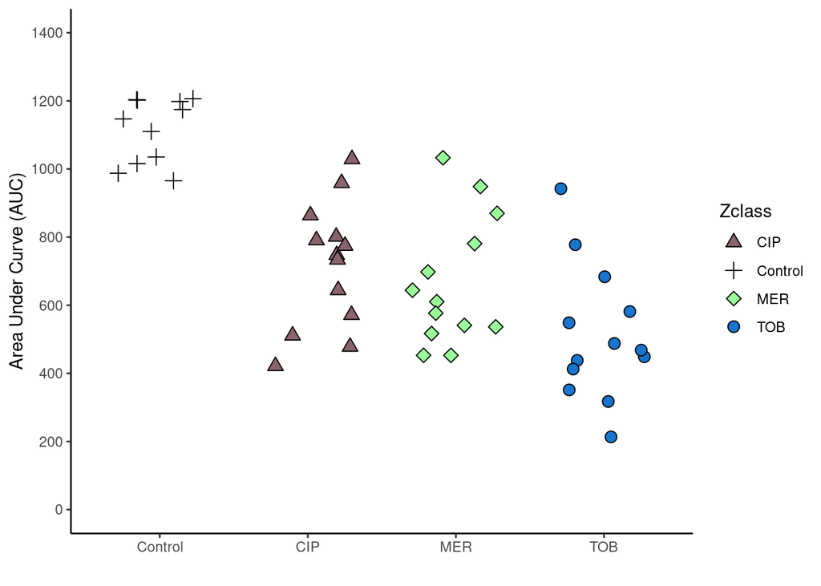

```r
GR_PL<- ggplot(JGR, aes(x=Zclass, y=auc_l))+ theme_classic() +
  geom_jitter(aes(fill = Zclass, shape=Zclass), width = 0.3, size=3, height = 0.25)+ scale_shape_manual(values=c(24,3,23,21))+
  scale_fill_manual(values = c("pink4","black","palegreen1","dodgerblue3")) +
  labs(x="", y="Area Under Curve (AUC)") + scale_x_discrete(limits=c("Control", "CIP", "MER", "TOB"))+
  scale_y_continuous(limits = c(0,1400), breaks=c(0,200,400,600,800,1000,1200,1400), labels = c(0,200,400,600,800,1000,1200,1400))

GR_PL
```

## Figure 3

This figure takes the predicted provean values for each variant identified against the panel of clinical and environmental genomes. Each variant is only listed a maximum of once per condition (clinical or environmental) to stop biasing different database sizes and to prevent bias from commonly occuring variants. Each variant was listed with its corresponding gene, antibiotic associated with resistance and a second associated resistance (if applicable) and finally a classification of environmental or clinical. Statistics were done on the raw provean scores against the type (environmental or clinical) and was an anova with Tukey correction.

```r
load("~/provean_newrun")
provean_newrun
```

```
##       GENE mutation PROVEAN TYPE ABR1 ABR2
##    1: tpiA     E21G  -5.410  env  CIP  MER
##    2: tpiA     E21D  -2.518  env  CIP  MER
##    3: tpiA     S33G  -1.009  env  CIP  MER
##    4: tpiA     S47G  -1.145  env  CIP  MER
##    5: tpiA     D59N   0.391  env  CIP  MER
##   ---
## 2529: rplF     G93D  -6.949 clin  TOB  TOB
## 2530: rplF     K95Q  -1.173 clin  TOB  TOB
## 2531: rplF    A119V  -1.493 clin  TOB  TOB
## 2532: rplF    Y157C  -8.783 clin  TOB  TOB
## 2533: rplF    G161S  -5.838 clin  TOB  TOB
```

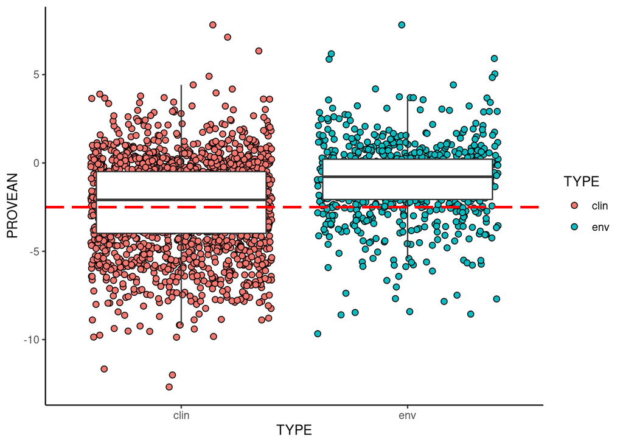

```r
provean_plot <- ggplot(provean_newrun, aes(x=TYPE, y=PROVEAN))+ theme_classic() +
  geom_jitter(aes(fill=TYPE), shape=21, size=2)+ geom_boxplot(outlier.shape = NA)+
  geom_hline(yintercept = c(-2.5), linetype="longdash", colour="red", size=1)
provean_plot
```

```r
provean.aov <- aov(PROVEAN ~ TYPE, data=provean_newrun)
provean.aov_cor <- TukeyHSD(provean.aov, p.adjust="bonferroni")
provean.aov_cor$TYPE[,"p adj"]
```

```
## [1] 0
```

## Supplementary figure 1

Adobe Illustrator artwork - no code used

## Supplementary figure 2

This figure shows the raw absorbance (OD600) values over 18 hours for each mutant. Line weights were increased in Adobe Illustrator, and PAO1 was changed to black to contrast it more clearly per antibiotic.

```r
require(Rmisc)
require(egg)

load("~/pXz01")
load("~/pd")
pXz01
```

```
##       time strain         abs
##    1:  0.0     T1 0.003000000
##    2:  0.5     T1 0.003333333
##    3:  1.0     T1 0.004666667
##    4:  1.5     T1 0.006333333
##    5:  2.0     T1 0.008666667
##   ---
## 1550: 16.0    T13 1.194666667
## 1551: 16.5    T13 1.079000000
## 1552: 17.0    T13 1.091000000
## 1553: 17.5    T13 1.113666667
## 1554: 18.0    T13 1.121333333
```

```r
tt00 <- summarySE(pXz01, measurevar="abs", groupvars=c("time", "strain"))
tt00$strain <- factor(tt00$strain, levels = c('T1','T2','T3','T4','T5','T6','T7','T8','T9','T10','T11','T12','T13','PAO'))
pltX <- ggplot(tt00, aes(x=time, y=abs, group=strain, colour=strain)) + theme_classic() + geom_line(position=pd, size=1) + geom_errorbar(aes(ymin=abs-se, ymax=abs+se), width=.1, position=pd) + geom_point(position=pd, shape=21, colour="black") + scale_x_continuous(breaks=c(0,2,4,6,8,10,12,14,16,18)) + labs(x="Time (h)", y="Absorbance 600nm") + guides(col=guide_legend(ncol = 2))

load("~/mXz01")
mXz01
```

```
##       time strain         abs
##    1:  0.0    PAO 0.001833333
##    2:  0.5    PAO 0.000416667
##    3:  1.0    PAO 0.001083333
##    4:  1.5    PAO 0.008166667
##    5:  2.0    PAO 0.026666667
##   ---
## 1550: 16.0    M13 1.006333333
## 1551: 16.5    M13 1.031833333
## 1552: 17.0    M13 1.053250000
## 1553: 17.5    M13 1.043666667
## 1554: 18.0    M13 1.033083333
```

```r
mm00 <- summarySE(mXz01, measurevar="abs", groupvars=c("time", "strain"))
mm00$strain <- factor(mm00$strain, levels = c('M1','M2','M3','M4','M5','M6','M7','M8','M9','M10','M11','M12','M13','PAO'))
pltY <- ggplot(mm00, aes(x=time, y=abs, group=strain, colour=strain)) + theme_classic()+ geom_line(position=pd, size=1) + geom_errorbar(aes(ymin=abs-se, ymax=abs+se), width=.1, position=pd) + geom_point(position=pd, shape=21, colour="black") + scale_x_continuous(breaks=c(0,2,4,6,8,10,12,14,16,18)) + labs(x="Time (h)", y="Absorbance 600nm") + guides(col=guide_legend(ncol = 2))

load("~/cXz01")
cXz01
```

```
##       time Strain   abs
##    1:  0.0    PAO 0.001
##    2:  0.5    PAO 0.000
##    3:  1.0    PAO 0.001
##    4:  1.5    PAO 0.003
##    5:  2.0    PAO 0.014
##   ---
## 2586: 16.0    C13 0.883
## 2587: 16.5    C13 0.905
## 2588: 17.0    C13 0.927
## 2589: 17.5    C13 0.933
## 2590: 18.0    C13 0.994
```

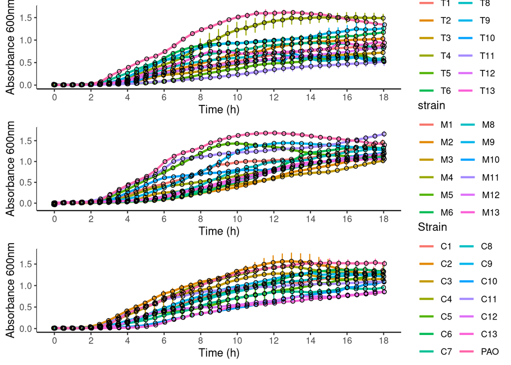

```r
cc00 <- summarySE(cXz01, measurevar="abs", groupvars=c("time", "Strain"))
cc00$Strain <- factor(cc00$Strain, levels = c('C1','C2','C3','C4','C5','C6','C7','C8','C9','C10','C11','C12','C13','PAO'))
pltZ <- ggplot(cc00, aes(x=time, y=abs, group=Strain, colour=Strain)) + theme_classic()+ geom_line(position=pd, size=1) + geom_errorbar(aes(ymin=abs-se, ymax=abs+se), width=.1, position=pd) + geom_point(position=pd, shape=21, colour="black") + scale_x_continuous(breaks=c(0,2,4,6,8,10,12,14,16,18)) + labs(x="Time (h)", y="Absorbance 600nm") + guides(col=guide_legend(ncol = 2))

combined_growth_plotXYZ <- ggarrange(pltX,pltY,pltZ, ncol = 1)
```

## Supplementary Figure 3

```r
require(multcomp)
require(egg)

load("~/tob123")
tob123
```

```
##     sample         k          n0           r    t_mid     t_gen     auc_l
##  1:      T 0.8152590 0.013023112 0.008431157 489.0683  82.24534  480.7999
##  2:     TA 0.9395495 0.023700159 0.006469297 565.9903 107.26328  483.5356
##  3:   PAO1 1.4739106 0.019535245 0.013068909 330.2861  53.09638 1103.4749
##  4:     TB 0.6604622 0.002765110 0.009787554 587.6354  72.57236  325.7173
##  5:     TC 1.3980666 0.009534784 0.009332200 539.7275  74.75657  754.6925
##  6:     TE 0.5736444 0.001355087 0.014006189 436.0338  49.78801  369.2375
##  7:     TF 1.1394632 0.031025218 0.011111250 380.6418  72.87058  791.1499
##  8:     TH 0.8848481 0.034341340 0.007617002 429.4107  92.63121  570.1284
##  9:     TI 0.5934900 0.000916964 0.022207494 345.1742  33.37379  435.2532
## 10:     TJ 1.1877311 0.018712012 0.010522406 414.9962  68.05063  787.0601
## 11:     TK 0.5191246 0.000974876 0.018767292 341.5894  37.45455  383.4643
## 12:     TL 0.4589366 0.001526562 0.008560225 670.5956  81.35701  189.2249
## 13:     TM 0.8866597 0.031770526 0.006524784 507.6767 106.77799  505.3620
## 14:     TN 0.8049183 0.002238818 0.016248231 381.4122  43.74182  561.3888
```

[output cut: 73 more lines]

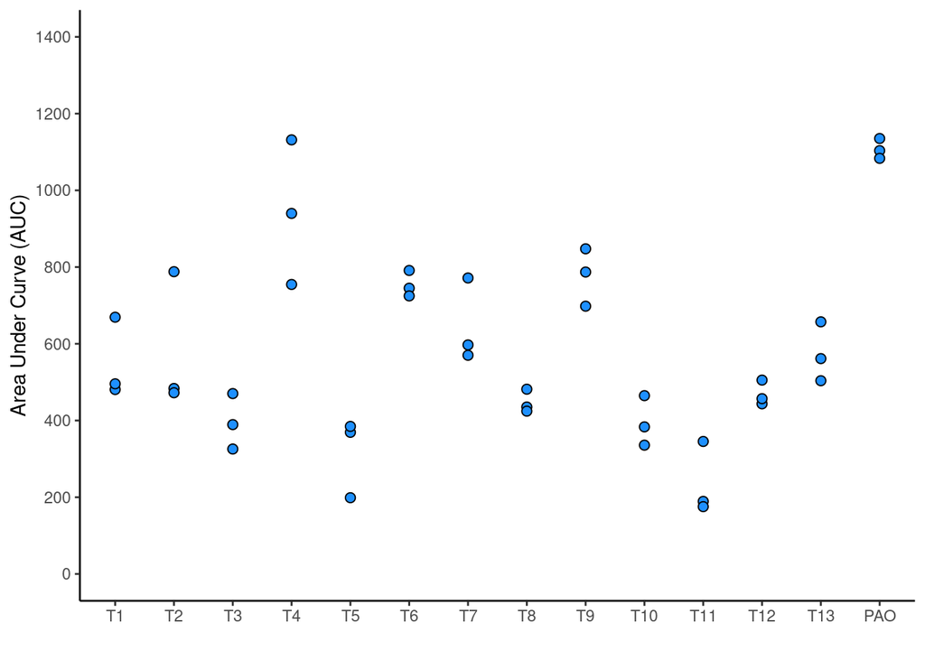

```r
T123_PL<- ggplot(tob123, aes(x=line, y=auc_l))+ theme_classic() +
  geom_point(shape =21, fill="dodgerblue", size=2.2)+ labs(x="", y="Area Under Curve (AUC)")+
  scale_y_continuous(limits = c(0,1400), breaks=c(0,200,400,600,800,1000,1200,1400), labels = c(0,200,400,600,800,1000,1200,1400)) + scale_x_discrete(limits=c("T1", "T2",  "T3",  "T4",  "T5",  "T6",  "T7",  "T8",  "T9", "T10", "T11", "T12", "T13", "PAO"))
T123_PL
```

```r
T123.aov <- aov(auc_l ~ line, data=tob123)
test.tob123 = glht(T123.aov, linfct = mcp(line = "Dunnett"))
summary(test.tob123, test=adjusted("bonferroni"))
```

```
##
##   Simultaneous Tests for General Linear Hypotheses
##
## Multiple Comparisons of Means: Dunnett Contrasts
##
##
## Fit: aov(formula = auc_l ~ line, data = tob123)
##
## Linear Hypotheses:
##                Estimate Std. Error t value Pr(>|t|)
## T1 - PAO == 0    -558.8       80.2  -6.967 1.84e-06 ***
## T10 - PAO == 0   -712.7       80.2  -8.886 1.59e-08 ***
## T11 - PAO == 0   -870.6       80.2 -10.856 1.98e-10 ***
## T12 - PAO == 0   -638.7       80.2  -7.964 1.47e-07 ***
## T13 - PAO == 0   -533.2       80.2  -6.649 4.23e-06 ***
## T2 - PAO == 0    -526.0       80.2  -6.559 5.36e-06 ***
## T3 - PAO == 0    -712.2       80.2  -8.881 1.61e-08 ***
## T4 - PAO == 0    -165.3       80.2  -2.061  0.63315
## T5 - PAO == 0    -789.8       80.2  -9.848 1.75e-09 ***
## T6 - PAO == 0    -353.7       80.2  -4.410  0.00180 **
## T7 - PAO == 0    -461.1       80.2  -5.749 4.68e-05 ***
## T8 - PAO == 0    -660.2       80.2  -8.232 7.60e-08 ***
## T9 - PAO == 0    -329.8       80.2  -4.112  0.00404 **
## ---
## Signif. codes:  0 '***' 0.001 '**' 0.01 '*' 0.05 '.' 0.1 ' ' 1
## (Adjusted p values reported -- bonferroni method)
```

```r
load("~/mero123")
mero123
```

```
##     sample         k          n0           r    t_mid     t_gen     auc_l
##  1:  APAO1 1.6202129 0.019605537 0.013099875 336.2094  52.93151 1203.5663
##  2:      M 1.1249984 0.017675165 0.010434886 401.5166  67.16322  758.0897
##  3:     MA 1.4471391 0.017766100 0.005956332 739.0949 116.58842  520.6154
##  4:     MB 1.1259981 0.038890297 0.004864622 697.5052 144.56789  450.5259
##  5:     MC 1.0389404 0.049882641 0.006091159 516.7252 120.31418  573.1077
##  6:     MD 1.3121127 0.007161638 0.015089276 346.4444  46.07171  961.5846
##  7:     ME 1.3908606 0.004869964 0.008411584 672.7486  82.48991  570.8090
##  8:     MG 1.1772075 0.013991550 0.006817749 650.3659 101.93523  512.3605
##  9:     MH 1.3741922 0.010982671 0.008033583 607.4181  86.94310  651.2280
## 10:     MI 1.4488656 0.007140404 0.010967442 489.3234  63.52469  855.0947
## 11:     MJ 1.0292021 0.047939167 0.009222177 372.9628  85.50981  713.5864
## 12:     MK 1.3413341 0.025985456 0.012201414 323.2400  56.99424 1012.6898
## 13:     ML 1.2347321 0.022842770 0.006116359 651.3136 113.66179  536.6935
## 14:     MN 1.0792186 0.013955585 0.008210597 556.8380  87.43824  564.7745
```

[output cut: 73 more lines]

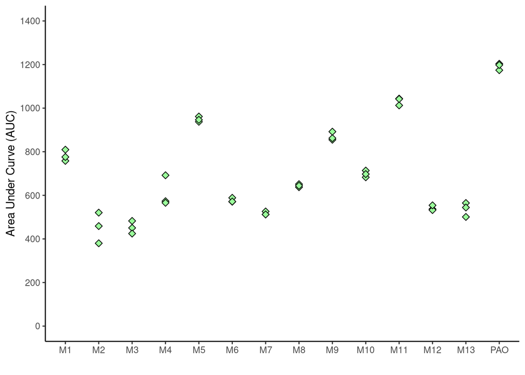

```r
M123_PL <- ggplot(mero123, aes(x=line, y=auc_l))+ theme_classic() +
  geom_point(shape =23, fill="palegreen1", size=2.2)+ labs(x="", y="Area Under Curve (AUC)")+
  scale_y_continuous(limits = c(0,1400), breaks=c(0,200,400,600,800,1000,1200,1400), labels = c(0,200,400,600,800,1000,1200,1400)) + scale_x_discrete(limits=c("M1", "M2", "M3", "M4", "M5", "M6", "M7", "M8", "M9", "M10", "M11", "M12", "M13", "PAO"))
M123_PL
```

```r
M123.aov <- aov(auc_l ~ line, data=mero123)
test.mer123 = glht(M123.aov, linfct = mcp(line= "Dunnett"))
summary(test.mer123, test=adjusted("bonferroni"))
```

```
##
##   Simultaneous Tests for General Linear Hypotheses
##
## Multiple Comparisons of Means: Dunnett Contrasts
##
##
## Fit: aov(formula = auc_l ~ line, data = mero123)
##
## Linear Hypotheses:
##               Estimate Std. Error t value Pr(>|t|)
## M10 - M1 == 0   -83.20      26.04  -3.196 0.044747 *
## M11 - M1 == 0   251.69      26.04   9.667 2.63e-09 ***
## M12 - M1 == 0  -240.06      26.04  -9.220 7.28e-09 ***
## M13 - M1 == 0  -244.51      26.04  -9.391 4.92e-09 ***
## M2 - M1 == 0   -327.93      26.04 -12.595 6.13e-12 ***
## M3 - M1 == 0   -328.56      26.04 -12.619 5.85e-12 ***
## M4 - M1 == 0   -170.83      26.04  -6.561 5.33e-06 ***
## M5 - M1 == 0    167.39      26.04   6.429 7.56e-06 ***
## M6 - M1 == 0   -204.14      26.04  -7.840 2.00e-07 ***
## M7 - M1 == 0   -264.29      26.04 -10.151 8.98e-10 ***
## M8 - M1 == 0   -136.90      26.04  -5.258 0.000178 ***
## M9 - M1 == 0     88.64      26.04   3.404 0.026250 *
## PAO - M1 == 0   410.77      26.04  15.777 2.31e-14 ***
## ---
## Signif. codes:  0 '***' 0.001 '**' 0.01 '*' 0.05 '.' 0.1 ' ' 1
## (Adjusted p values reported -- bonferroni method)
```

```r
load("~/cipr123")
cipr123
```

```
##     sample         k          n0           r    t_mid     t_gen     auc_l
##  1:   PAO1 1.8930226 0.046406129 0.007808366 471.7605  88.76981 1147.4837
##  2: PAO1.1 1.4357824 0.044392485 0.008518458 404.4145  81.37003  965.2331
##  3: PAO1.2 1.4745845 0.042636170 0.008627455 407.3146  80.34203  987.4315
##  4: PAO1.3 1.3700264 0.025116784 0.011814692 336.9149  58.66824 1015.9184
##  5: PAO1.4 1.4444073 0.027822502 0.010869443 361.5787  63.77026 1035.1623
##  6:    CA7 1.0964196 0.004574759 0.014054541 389.5588  49.31838  756.6919
##  7:  CA7.1 1.0734898 0.014831566 0.010560039 404.1652  65.63870  724.1683
##  8:  CA7.2 1.1207627 0.017659773 0.010421473 396.7379  66.51144  764.1535
##  9:  CA7.3 1.8718996 0.054085927 0.005011328 701.3741 138.31607  749.9891
## 10:  CA7.4 1.6927409 0.053890897 0.005213880 654.9419 132.94267  742.6046
## 11:    CB7 1.2630731 0.014518715 0.015281052 291.4919  45.35991  994.9882
## 12:  CB7.1 1.1585019 0.015066308 0.016314401 265.3687  42.48683  942.8224
## 13:  CB7.2 1.2193487 0.029012045 0.012833186 289.4278  54.01209  961.6989
## 14:  CB7.3 1.8042401 0.021717032 0.009836948 448.0748  70.46364 1138.2896
```

[output cut: 129 more lines]

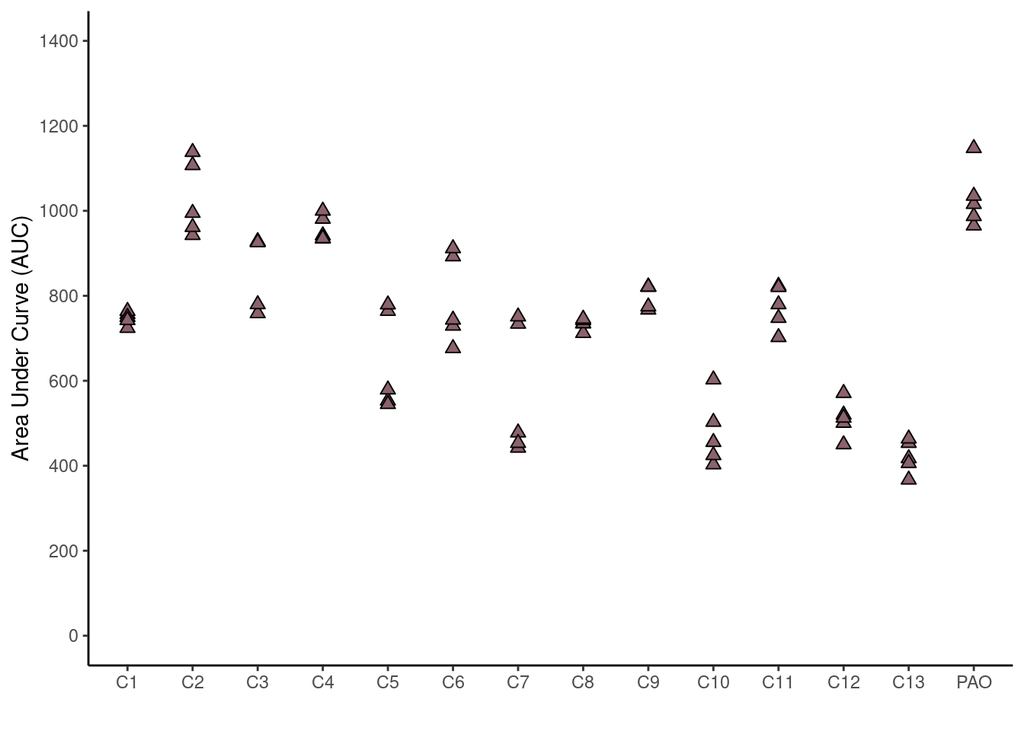

```r
C123_PL <- ggplot(cipr123, aes(x=group, y=auc_l))+ theme_classic() +
  geom_point(shape =24, fill="pink4", size=2.2)+ labs(x="", y="Area Under Curve (AUC)")+
  scale_y_continuous(limits = c(0,1400), breaks=c(0,200,400,600,800,1000,1200,1400), labels = c(0,200,400,600,800,1000,1200,1400)) + scale_x_discrete(limits=c("C1", "C2",  "C3",  "C4",  "C5",  "C6",  "C7",  "C8",  "C9", "C10", "C11", "C12", "C13", "PAO"))
C123_PL
```

```r
C123.aov <- aov(auc_l ~ group, data=cipr123)
test.cip123 = glht(C123.aov, linfct = mcp(group = "Dunnett"))
summary(test.cip123, test=adjusted("bonferroni"))
```

```
##
##   Simultaneous Tests for General Linear Hypotheses
##
## Multiple Comparisons of Means: Dunnett Contrasts
##
##
## Fit: aov(formula = auc_l ~ group, data = cipr123)
##
## Linear Hypotheses:
##               Estimate Std. Error t value Pr(>|t|)
## C10 - C1 == 0  -269.61      48.97  -5.505 1.24e-05 ***
## C11 - C1 == 0    27.22      48.97   0.556 1.000000
## C12 - C1 == 0  -236.49      48.97  -4.829 0.000143 ***
## C13 - C1 == 0  -325.89      48.97  -6.654 1.67e-07 ***
## C2 - C1 == 0    281.50      48.97   5.748 5.06e-06 ***
## C3 - C1 == 0    116.55      48.97   2.380 0.269729
## C4 - C1 == 0    211.12      48.97   4.311 0.000864 ***
## C5 - C1 == 0   -103.27      48.97  -2.109 0.513093
## C6 - C1 == 0     43.26      48.97   0.883 1.000000
## C7 - C1 == 0   -175.74      48.97  -3.588 0.009100 **
## C8 - C1 == 0    -13.44      48.97  -0.274 1.000000
## C9 - C1 == 0     53.60      48.97   1.094 1.000000
## PAO - C1 == 0   282.72      48.97   5.773 4.61e-06 ***
## ---
## Signif. codes:  0 '***' 0.001 '**' 0.01 '*' 0.05 '.' 0.1 ' ' 1
## (Adjusted p values reported -- bonferroni method)
```

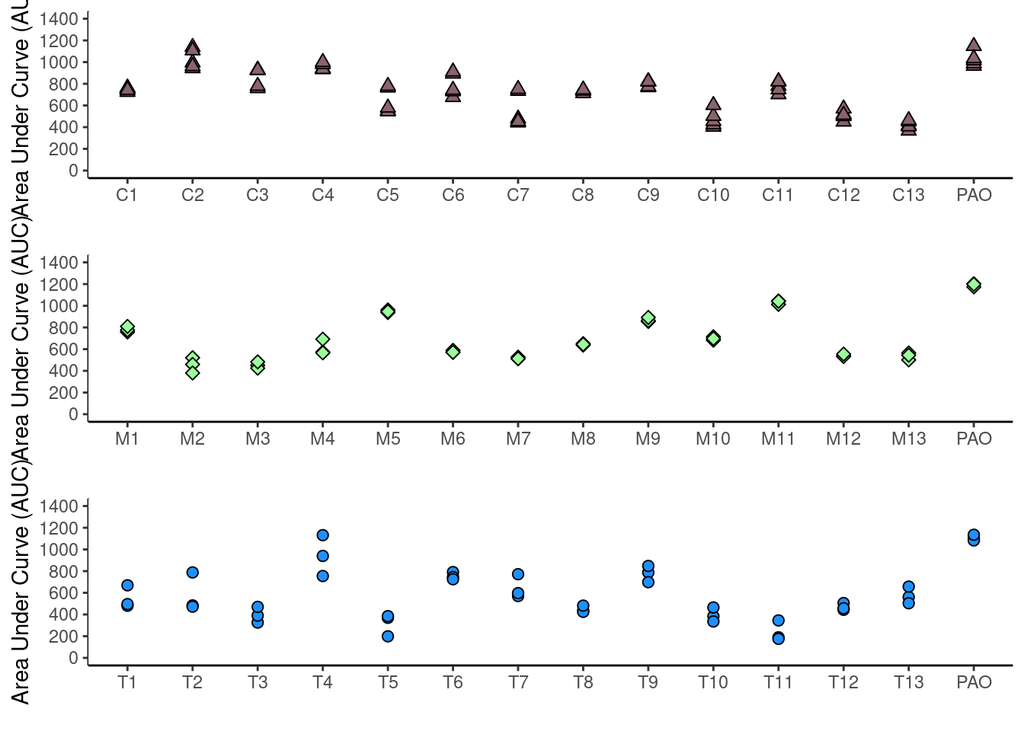

```r
ggarrange(C123_PL,M123_PL,T123_PL, ncol=1)
```

## Supplementary Figure 4

BRIG figure - See other codes

## Supplementary Figure 5

These figures serve to show copy number variation across some of the experimentally evolved isolates. A “hits” file was generated from BAM files of the mutant mapped onto P.aeruginosa PAO1 (the documentation for CNOGpro details how this is done). Those hits files were loading into R using the PAO1.gbff file from RefSeq as a reference and used a window length of 100 (takes the mean read number across 100bp frames to reduce computing time and artifacts from reducing window size too small). A series of normalizations are then carried out to make sure the data can be compared across isolates and bootstrapped for 1000 replicates to give higher confidence in results. Originally we used 3 possible states of copy number (0 (doesnt count),1,2,3). There is regions in the PAO1 genome found in higher copy than this, however too many states makes the results harder to determine a true duplication from an artifact introduced from including too many possible copy number states (3 was the best for this data, other data and longer read data might benefit from more states), this can be seen in the read count distribution figures

```r
require(CNOGpro)

#importing files
#PAO1_CNOG <- CNOGpro(hitsfile = "PAO1.hits", gbkfile = "PAO1.gbff", windowlength = 100, name = "P.aeruginosa M1")
load("~/PAO1_CNOG")
PAO1_CNOG
```

```
## $Name
## [1] "P.aeruginosa M1"
##
## $windowlength
## [1] 100
##
## $accession
## [1] "NC_002516"
##
## $genes
##       Type    Locus Strand    Left   Right Length
## 1       IG               1       1     482    482
## 2      CDS   PA0001      1     483    2027   1545
## 3       IG               1    2028    2055     28
## 4      CDS   PA0002      1    2056    3159   1104
```

[output cut: 18888 more lines]

```r
PAO1_CNOG_NORM <- normalizeGC(PAO1_CNOG)
```

```
## Normalizing read counts for GC bias...
## Overall values for chromosome  NC_002516 :
## Median read count:  55
## Median GC percentage:  0.67
## Calculating per-read weight based on GC percentage...
## Successfully normalized chromosome  NC_002516
```

```r
PAO1_CNOG_BS <- runBootstrap(PAO1_CNOG_NORM, replicates = 1000, quantiles = c(0.025, 0.975))
```

```
## Starting bootstrap analysis for NC_002516 - This might take a while...
##
## Finished bootstrap analysis.
```

```r
PAO1_CNOG_HMM <- runHMM(PAO1_CNOG_BS, nstates = 3, changeprob = 1e-05, includeZeroState = T, errorRate = 0.01)
```

[output not shown]

[output cut: 40 more lines]

```
## Positions 5267501 - 5268600 : Most probable state =  3
## Positions 5268601 - 5268800 : Most probable state =  2
## Positions 5268801 - 5381500 : Most probable state =  1
## Positions 5381501 - 5382900 : Most probable state =  3
## Positions 5382901 - 6038500 : Most probable state =  1
## Positions 6038501 - 6042800 : Most probable state =  3
## Positions 6042801 - 6042900 : Most probable state =  1
## Positions 6042901 - 6043000 : Most probable state =  2
## Positions 6043001 - 6044100 : Most probable state =  3
## Positions 6044101 - 6093500 : Most probable state =  1
## Positions 6093501 - 6093600 : Most probable state =  2
## Positions 6093601 - 6263400 : Most probable state =  1
## Positions 6263401 - 6264404 : Most probable state =  0
## Finished running Viterbi algorithm. Assigning most probable states to individual segments...
## Copy number analysis complete. Use print to access results.
```

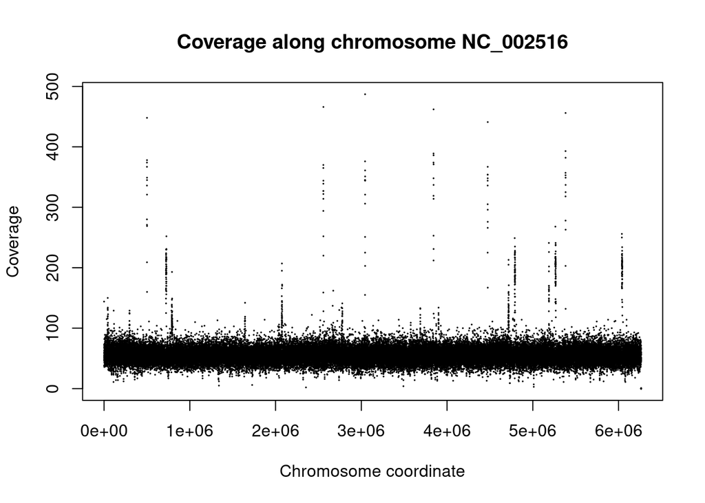

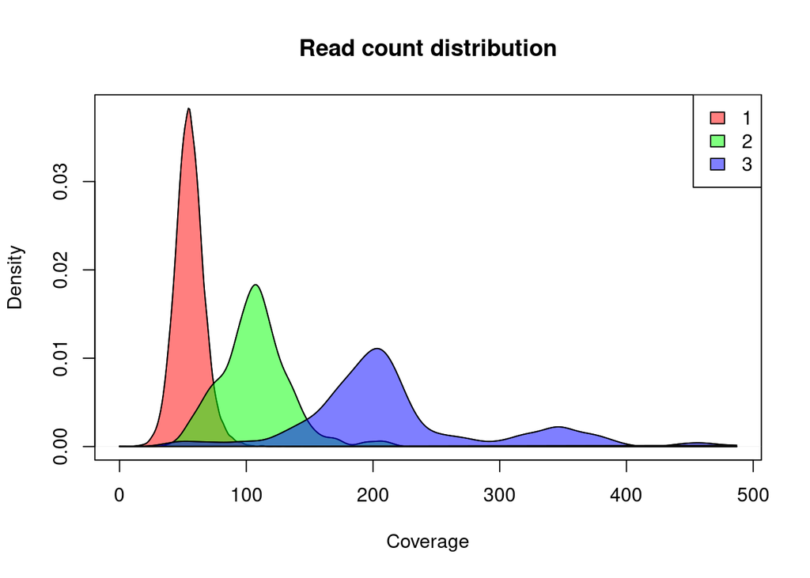

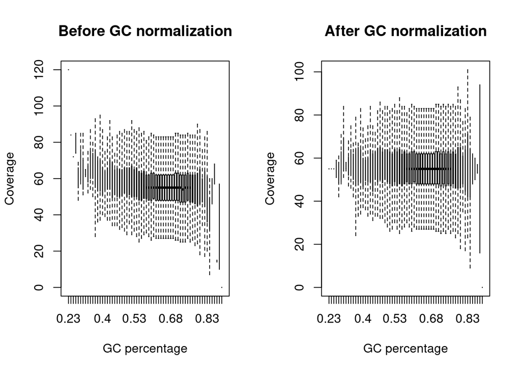

```r
plotCNOGpro(PAO1_CNOG_HMM)
```

```r
#importing files
#TE_CNOG <- CNOGpro(hitsfile = "TE.hits", gbkfile = "PAO1.gbff", windowlength = 100, name = "P.aeruginosa M1")
#TE_CNOG_NORM <- normalizeGC(TE_CNOG)
#TE_CNOG_BS <- runBootstrap(TE_CNOG_NORM, replicates = 1000, quantiles = c(0.025, 0.975))
#TE_CNOG_HMM <- runHMM(TE_CNOG_BS, nstates = 3, changeprob = 1e-05, includeZeroState = T, errorRate = 0.01)
#plotCNOGpro(TE_CNOG_HMM)

#importing files
#TK_CNOG <- CNOGpro(hitsfile = "TK.hits", gbkfile = "PAO1.gbff", windowlength = 100, name = "P.aeruginosa M1")
#TK_CNOG_NORM <- normalizeGC(TK_CNOG)
#TK_CNOG_BS <- runBootstrap(TK_CNOG_NORM, replicates = 1000, quantiles = c(0.025, 0.975))
#TK_CNOG_HMM <- runHMM(TK_CNOG_BS, nstates = 3, changeprob = 1e-05, includeZeroState = T, errorRate = 0.01)
#plotCNOGpro(TK_CNOG_HMM)

#importing files
#M12_CNOG <- CNOGpro(hitsfile = "M12.hits", gbkfile = "PAO1.gbff", windowlength = 100, name = "P.aeruginosa M1")
load("~/M12_CNOG")
M12_CNOG_NORM <- normalizeGC(M12_CNOG)
```

```
## Normalizing read counts for GC bias...
## Overall values for chromosome  NC_002516 :
## Median read count:  39
## Median GC percentage:  0.67
## Calculating per-read weight based on GC percentage...
## Successfully normalized chromosome  NC_002516
```

```r
M12_CNOG_BS <- runBootstrap(M12_CNOG_NORM, replicates = 1000, quantiles = c(0.025, 0.975))
```

```
## Starting bootstrap analysis for NC_002516 - This might take a while...
##
## Finished bootstrap analysis.
```

```r
M12_CNOG_HMM <- runHMM(M12_CNOG_BS, nstates = 3, changeprob = 1e-05, includeZeroState = T, errorRate = 0.01)
```

[output not shown]

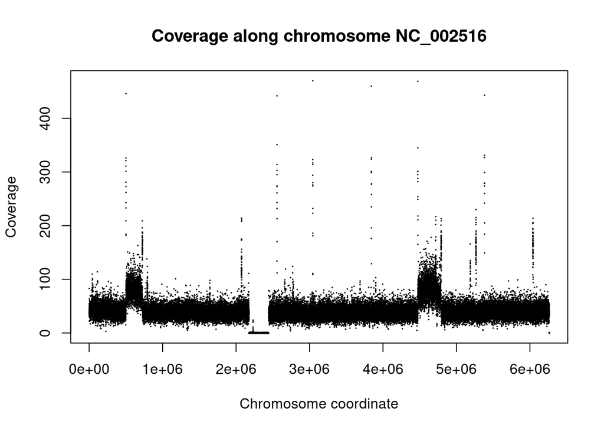

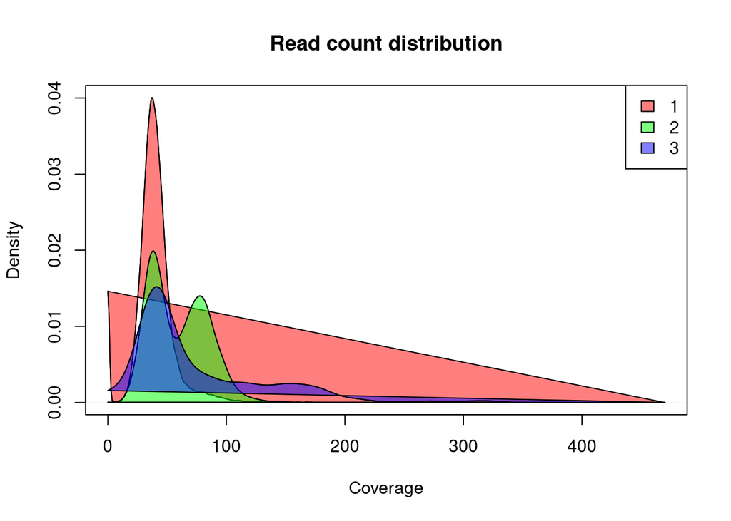

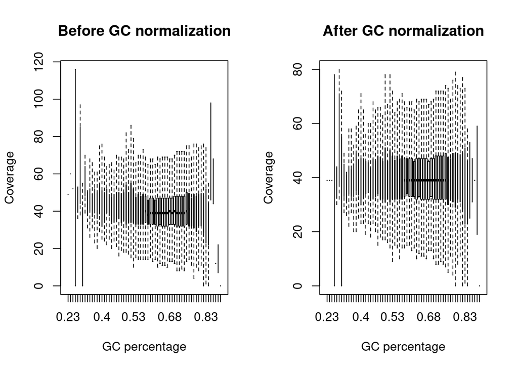

```r
plotCNOGpro(M12_CNOG_HMM)
```

## Supplementary Figure 6

BRIG figure - See other codes